# Презентация по лабораторной работе №3

Иммитационное моделирование

Арбатова Варвара Петровна

1132236020@rudn.ru

Российский университет дружбы народов

2026-03-21

# Информация

## Докладчик

- Арбатова Варвара Петровна
- студентка
- Российский университет дружбы народов им. П. Лумумбы
- [1132236020@rudn.ru]
- https://vparbatova.github.io/ru/

# Теоретическое введение

## Агентный подход

Агентный подход к имитационному моделированию (Agent-Based Modeling, ABM) — это метод исследования сложных систем, в котором поведение системы возника- ет из взаимодействия множества автономных сущностей, называемых агентами. Вместо того чтобы описывать систему глобальными уравнениями, мы моделиру- ем каждую индивидуальную единицу и правила её поведения, а затем наблюдаем, какие коллективные паттерны появляются снизу вверх. Этот подход особенно полезен, когда поведение системы трудно предсказать из-за нелинейностей, ге- терогенности участников или адаптивных стратегий.

## Условия задачи

В модели Daisyworld агентами являются чёрные и белые маргаритки. Они живут на клеточной сетке (среда). Свойства агентов: вид и возраст. Правила:

— Маргаритки изменяют локальную температуру за счёт разного альбедо.

— Температура влияет на вероятность размножения (чем ближе к оптимуму, тем выше шанс заселить соседнюю пустую клетку).

— Агенты стареют и умирают после определённого возраста.

— Среда (температура) диффундирует между клетками.

# Выполнение лабораторной работы

## Выполнение лабораторной работы

Создаю файл, в котором будет храниться информация об агентах(рис. 1)

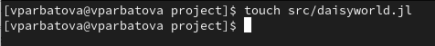

Рисунок 1: Создаю файл

## Выполнение лабораторной работы

Запускаю этот файл (рис. 2)

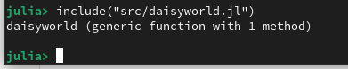

Рисунок 2: Запуск файла

## Выполнение лабораторной работы

Создаю файл, в котором будет проходить симулция и рисоваться графики (рис. 3)

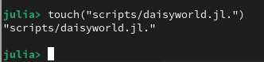

Рисунок 3: Создание файла

## Выполнение лабораторной работы

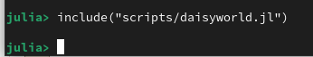

Рисунок 4: Запуск файла

## Выполнение лабораторной работы

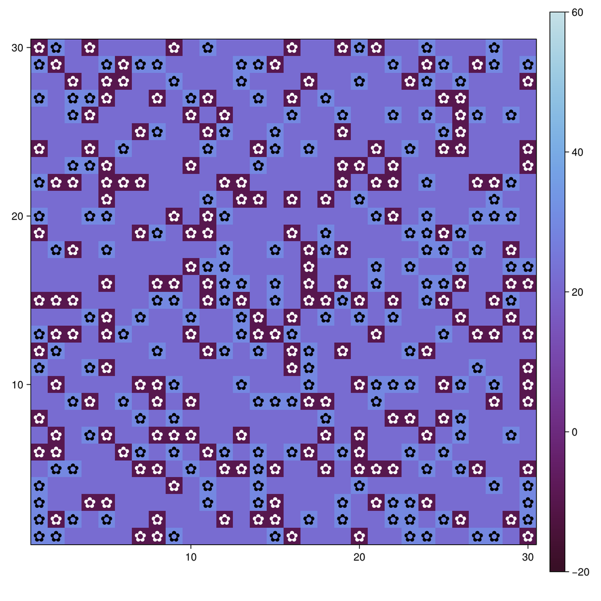

Рисунок 5: Начальное состояние

## Выполнение лабораторной работы

Состояние поля через 5 единиц времени (рис. 6)

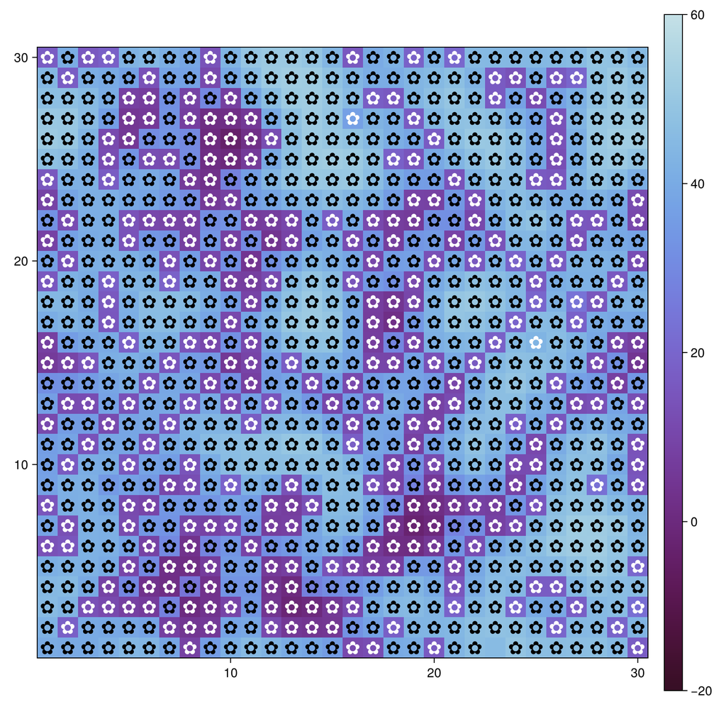

Рисунок 6: Состояние через 5 единиц времени

## Выполнение лабораторной работы

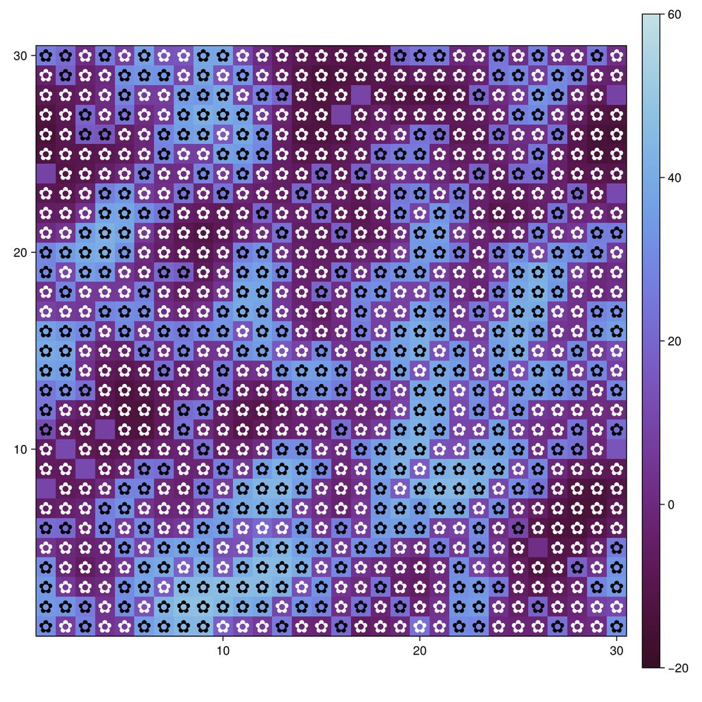

Рисунок 7: Состояние через 40 единиц времени

## Анализ результатов. Динамика количества ромашек (daisy_count)

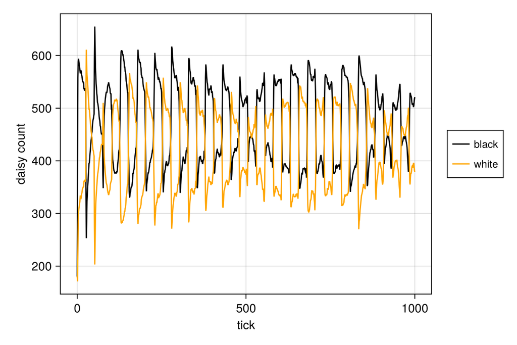

Рисунок 8

## Анализ результатов. Влияние солнечной светимости (daisy_luminosity)

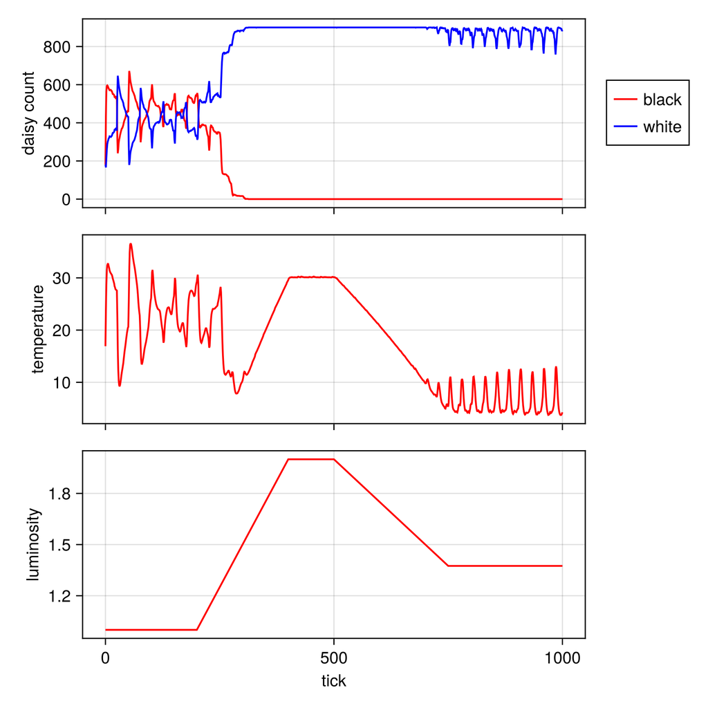

Рисунок 9

## Анализ файлов с параметрами

| Файл | Входные параметры | Выходные данные | Что выявляет |
| --- | --- | --- | --- |
| daisyworld__param.jl | `max_age`, `init_white` | Тепловые карты (3 временных среза) | Пространственную самоорганизацию |
| daisyworld-count__param.jl | `max_age`, `init_white` | Графики численности | Динамику конкуренции видов |
| daisyworld-luminosity__param.jl | `max_age`, `init_white` + сценарий `:ramp` | Комплексные графики | Регуляторную способность и гистерезис |

# Заключение

## Вывод

- Реализована агентная модель Daisyworld.
- Продемонстрирован эффект саморегуляции.
- Подтверждена гипотеза Геи.

# Выводы

Я получила опыт работы с агентным подходом